# Neena Varanasi

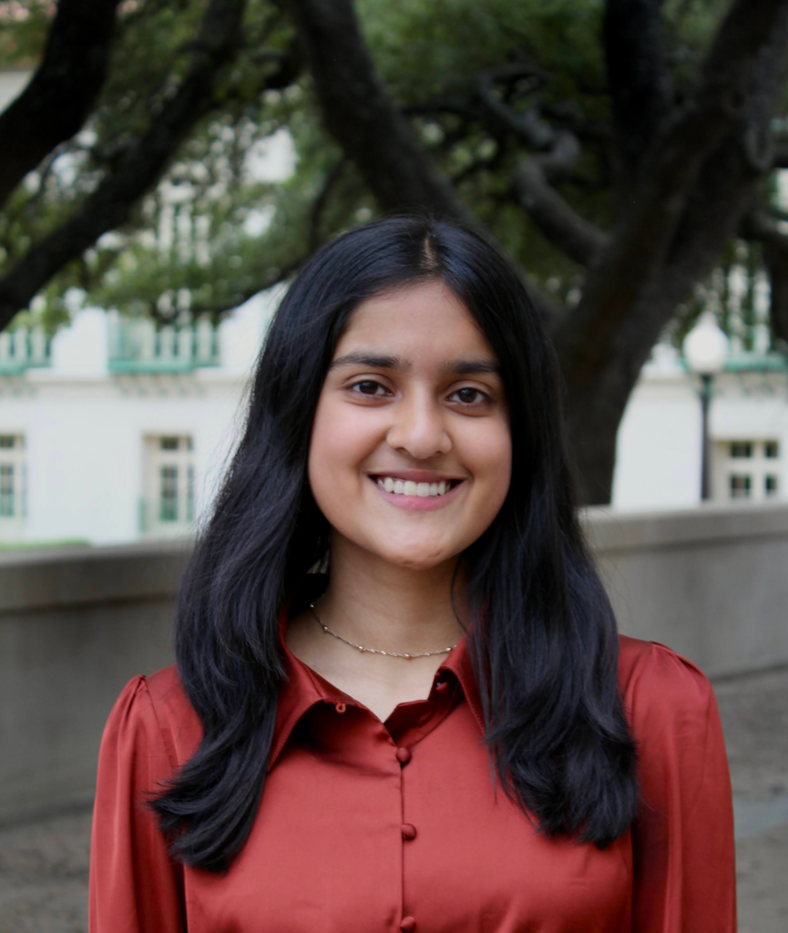

### Neena Varanasi

B.S./M.S. in Statistics (4+1) & Data Science  
University of Texas at Austin  
Class of 2028

- Resume
- [GitHub](https://github.com/Neena05)
- [LinkedIn](https://www.linkedin.com/in/neena-varanasi)

# About Me

Neena Varanasi is a senior in the 4+1 Master's program in Statistics (undergraduate degree in Statistics and Data Science) at the University of Texas at Austin, Class of May 2028. She is a member of the Polymathic Honors Program, is pursuing a certificate in Programming and Computation, and is minoring in Business and Public Policy. Outside of school, she loves listening to music, trying new restaurants, and traveling.

## Projects

### [Psychiatric Disorders Research Spotlight](https://docs.google.com/presentation/d/1rtevznuI4eqKab0YpQJnWnPt-mtpy9PW/edit?usp=sharing&ouid=106448567148067858727&rtpof=true&sd=true)

Python, R, SVM, RNA-Seq · April 2025

Research project on classifying psychiatric disorders with brain and blood transcriptomic expression. Utilized machine learning feature selection tools and statistical testing.

### [Daily Texan Story Spotlight](https://thedailytexan.com/2025/04/22/local-businesses-on-guad-ride-austins-economic-waves-through-the-decades/)

Python, Pandas, Data Visualization · April 2025

One of my favorite Daily Texan stories I worked on was "Local businesses on Guad ride Austin's economic waves through the decades." I cleaned and combined data from 5+ sources to create the three graphs, showing how local businesses mirror Austin's economic ups and downs.

### Analysis of Emotional Responses to Music Through EEG

Python, Signal Processing, EEG · May 2025

Predicted emotions felt by participants listening to film music clips using EEG data by modeling mean voltages across electrodes to identify the strongest reported emotion for each subject.

### [ALSpeak](https://www.canva.com/design/DAGVwcM4rZ8/AiJ9NiL2KEFKPfLV2GiWLg/edit?utm_content=DAGVwcM4rZ8&utm_campaign=designshare&utm_medium=link2&utm_source=sharebutton)

React Native, Expo, Firebase · December 2024

Developed ALS communication app with context-aware features and natural voice replication. Built with React Native, Expo, and Firebase; won Best Business out of 20+ teams at Convergent.

### [Predicting Grammy Award Winners](https://docs.google.com/presentation/d/1P4WxhY-2f9dtdVNsPwbSTlfPHEAENbInkWSavk7-ym8/edit?usp=sharing)

BERT, Logistic Regression, SMOTE · December 2024

Built BERT and Logistic Regression models on Pitchfork review data using SMOTE and synthetic generation. Achieved strong classification performance predicting Grammy winners from music reviews.

### [Gene Expression Profiling in Glioblastoma](https://docs.google.com/presentation/d/1EwZgOxFjvyW92tEBJ9P29HFSX4dv85XzhZ1HouvF004/edit?usp=sharing)

Python, KNN, PCA · May 2024

Created ML pipeline with KNN and PCA to identify glioblastoma biomarkers; won 1st place in lab competition. Reached 80%+ accuracy in distinguishing control vs tumor samples for early diagnosis.

## Experience

### Department of Statistics & Data Science, UT Austin

Machine Learning Undergraduate Course Assistant · Austin, TX · August 2026 – Present

### IBM

Data Science Intern · Austin, TX · May 2026 – August 2026

### AstraZeneca

Operations Data Science Intern · Coppell, TX · May 2025 – December 2025

### The Daily Texan

Data Scientist · January 2025 – Present

### Big Data in Biology Lab, UT Austin

Undergraduate Peer Mentor & Research Assistant · January 2024 – Present

### First Principles Dental Training

Software Engineer · February 2025 – May 2025

## Relevant Coursework

**Statistics & Mathematics** Probability and Statistical Inference, Mathematical Statistics I, Regression Analysis, Advanced Statistical Methods, Intermediate Statistical Methods, Statistical Thinking, Linear Algebra/Matrix Theory (Honors), Discrete Mathematics

**Computer Science** Elements of Software Design, Elements of Databases, Elements of Data Visualization, Introduction to Data Science

**Machine Learning & Applied Data Science** Practical Machine Learning, Machine Learning Text Analysis, Data Product Development, Big Data in Biology (FRI), Bias

Last built on October 01, 2026 at 14:23:46 CDT